# SOLUTIONS - Markov Sick-Sicker model in R - Excerise

With simulation-time dependence

The DARTH workgroup

This work is developed by the Decision Analysis in R for Technologies in Health (DARTH) workgroup:

- Fernando Alarid-Escudero, PhD
- Eva A. Enns, MS, PhD
- M.G. Myriam Hunink, MD, PhD
- Hawre J. Jalal, MD, PhD
- Eline Krijkamp, PhD
- Petros Pechlivanoglou, PhD
- Alan Yang, MSc

Please acknowledge our work. See details to cite below.

See student template for excersice description.

Change `eval` to `TRUE` if you want to knit this document.

```r
rm(list = ls())      # clear memory (removes all the variables from the workspace)
```

# 01 Load packages

```r
if (!require('pacman')) install.packages('pacman'); library(pacman) # use this package to conveniently install other packages
# load (install if required) packages from CRAN
p_load("dplyr", "tidyr", "reshape2", "devtools", "scales", "ellipse", "ggplot2", "ggrepel", "gridExtra", "lazyeval", "igraph", "truncnorm", "ggraph", "reshape2", "patchwork", "knitr", "stringr", "diagram", "dampack")
# load (install if required) packages from GitHub
# install_github("DARTH-git/darthtools", force = TRUE) #Uncomment if there is a newer version
p_load_gh("DARTH-git/darthtools")
```

# 02 Load functions

```r
# all functions are in the darthtools package
```

# 03 Model input

```r
## General setup
cycle_length <- 1   # cycle length equal to one year (use 1/12 for monthly)
n_age_init   <- 25  # age at baseline
n_age_max    <- 100 # maximum age of follow up
n_cycles     <- (n_age_max - n_age_init)/cycle_length # time horizon, number of cycles
# Age labels
v_age_names  <- paste(rep(n_age_init:(n_age_max-1), each = 1/cycle_length),
                      1:(1/cycle_length),
                      sep = ".")
# the 4 health states of the model:
v_names_states <- c("H",  # Healthy (H)
                    "S1", # Sick (S1)
                    "S2", # Sicker (S2)
                    "D")  # Dead (D)

n_states <- length(v_names_states)   # number of health states

### Discounting factors
# Comment out/ for the relevant country
# USA
#d_c <- d_e <- 0.03  # annual discount rate for costs and QALY
# Canada
#d_c <- d_e <- 0.015 # annual discount rate for costs

# NL
d_c <- 0.03         # annual discount rate for costs
d_e <- 0.015        # annual discount rate for QALYs


### Strategies
v_names_str <- c("Standard of care", # store the strategy names
                 "Strategy AB")
n_str       <- length(v_names_str)   # number of strategies

## Within-cycle correction (WCC) using Simpson's 1/3 rule
v_wcc  <- gen_wcc(n_cycles = n_cycles, method = "Simpson1/3")

### Transition rates (annual), and hazard ratios (HRs)
r_HS1  <- 0.15  # constant annual rate of becoming Sick when Healthy
r_S1H  <- 0.5   # constant annual rate of becoming Healthy when Sick
r_S1S2 <- 0.105 # constant annual rate of becoming Sicker when Sick
hr_S1  <- 3     # hazard ratio of death in Sick vs Healthy
hr_S2  <- 10    # hazard ratio of death in Sicker vs Healthy

### Effectiveness of treatment AB
hr_S1S2_trtAB <- 0.6  # hazard ratio of becoming Sicker when Sick under treatment AB

## Age-dependent mortality rates
lt_usa_2015 <- read.csv("../data/HMD_USA_Mx_2015.csv")
# Extract age-specific all-cause mortality for ages in model time horizon
v_r_mort_by_age <- lt_usa_2015 %>%
  dplyr::filter(Age >= n_age_init & Age < n_age_max) %>%
  dplyr::select(Total) %>%
  as.matrix()

### State rewards
#### Costs
c_H     <- 2000  # annual cost of being Healthy
c_S1    <- 4000  # annual cost of being Sick
c_S2    <- 15000 # annual cost of being Sicker
c_D     <- 0     # annual cost of being dead
c_trtAB <- 25000 # annual cost of receiving treatment AB
#### Utilities
u_H     <- 1     # annual utility of being Healthy
u_S1    <- 0.75  # annual utility of being Sick
u_S2    <- 0.5   # annual utility of being Sicker
u_D     <- 0     # annual utility of being dead
u_trtAB <- 0.95  # annual utility when receiving treatment AB

### Discount weight for costs and effects
v_dwc   <- 1 / ((1 + (d_e * cycle_length)) ^ (0:n_cycles))
v_dwe   <- 1 / ((1 + (d_c * cycle_length)) ^ (0:n_cycles))

# Process model inputs
## Age-specific transition rates to the Dead state for all cycles
v_r_HD_age  <- rep(v_r_mort_by_age, each = 1/cycle_length)
# Name age-specific mortality vector
names(v_r_HD_age) <- v_age_names

# compute mortality rates
v_r_S1D_age  <- v_r_HD_age * hr_S1 # Age-specific mortality rate in the Sick state
v_r_S2D_age  <- v_r_HD_age * hr_S2 # Age-specific mortality rate in the Sicker state
# transform rates to probabilities adjusting by cycle length
p_HS1       <- rate_to_prob(r = r_HS1,  t = cycle_length) # constant annual probability of becoming Sick when Healthy conditional on surviving
p_S1H       <- rate_to_prob(r = r_S1H,  t = cycle_length) # constant annual probability of becoming Healthy when Sick conditional on surviving
p_S1S2      <- rate_to_prob(r = r_S1S2, t = cycle_length) # constant annual probability of becoming Sicker when Sick conditional on surviving
v_p_HD_age   <- rate_to_prob(v_r_HD_age,  t = cycle_length) # Age-specific mortality risk in the Healthy state
v_p_S1D_age  <- rate_to_prob(v_r_S1D_age, t = cycle_length) # Age-specific mortality risk in the Sick state
v_p_S2D_age  <- rate_to_prob(v_r_S2D_age, t = cycle_length) # Age-specific mortality risk in the Sicker state

## Annual transition probability of becoming Sicker when Sick for treatment AB
# Apply hazard ratio to rate to obtain transition rate of becoming Sicker when Sick for treatment AB
r_S1S2_trtAB <- r_S1S2 * hr_S1S2_trtAB
# Transform rate to probability to become Sicker when Sick under treatment AB
# adjusting by cycle length conditional on surviving
p_S1S2_trtAB <- rate_to_prob(r = r_S1S2_trtAB, t = cycle_length)
```

# 04 Construct state-transition models

## 04.1 Initial state vector

```r
# All starting healthy
v_m_init <- c(H = 1, S1 = 0, S2 = 0, D = 0) # initial state vector
v_m_init
```

```
##  H S1 S2  D
##  1  0  0  0
```

## 04.2 Initialize cohort traces

```r
### Initialize cohort trace under SoC
m_M_SoC <- matrix(NA,
              nrow = (n_cycles + 1), ncol = n_states,
              dimnames = list(0:n_cycles, v_names_states))
# Store the initial state vector in the first row of the cohort trace
m_M_SoC[1, ] <- v_m_init

### Initialize cohort trace for strategy AB
# Structure and initial states are the same as for SoC
m_M_strAB <- m_M_SoC # Strategy AB
```

## 04.3 Create transition probability matrices

```r
## Create transition probability arrays for strategy SoC
### Initialize transition probability array for strategy SoC
# All transitions to a non-death state are assumed to be conditional on survival
a_P_SoC <- array(0,
                 dim  = c(n_states, n_states, n_cycles),
                 dimnames = list(v_names_states,
                                 v_names_states,
                                 0:(n_cycles - 1)))
### Fill in array
## From H
a_P_SoC["H", "H", ]   <- (1 - v_p_HD_age) * (1 - p_HS1)
a_P_SoC["H", "S1", ]  <- (1 - v_p_HD_age) *      p_HS1
a_P_SoC["H", "D", ]   <-      v_p_HD_age
## From S1
a_P_SoC["S1", "H", ]  <- (1 - v_p_S1D_age) *       p_S1H
a_P_SoC["S1", "S1", ] <- (1 - v_p_S1D_age) * (1 - (p_S1H + p_S1S2))
a_P_SoC["S1", "S2", ] <- (1 - v_p_S1D_age) *               p_S1S2
a_P_SoC["S1", "D", ]  <-      v_p_S1D_age
## From S2
a_P_SoC["S2", "S2", ] <- 1 - v_p_S2D_age
a_P_SoC["S2", "D", ]  <-     v_p_S2D_age
## From D
a_P_SoC["D", "D", ]   <- 1

### Initialize transition probability array for strategy AB
a_P_strAB <- a_P_SoC
# Update only transition probabilities from S1 involving p_S1S2
a_P_strAB["S1", "S1", ] <- (1 - v_p_S1D_age) * (1 - (p_S1H + p_S1S2_trtAB))
a_P_strAB["S1", "S2", ] <- (1 - v_p_S1D_age) *               p_S1S2_trtAB

## Check if transition probability arrays are valid
### Check that transition probabilities are [0, 1]
check_transition_probability(a_P_SoC,   verbose = TRUE)
```

```
## [1] "Valid transition probabilities"
```

```r
check_transition_probability(a_P_strAB, verbose = TRUE)
```

```
## [1] "Valid transition probabilities"
```

```r
### Check that all rows for each slice of the array sum to 1
check_sum_of_transition_array(a_P_SoC,   n_states = n_states, n_cycles = n_cycles, verbose = TRUE)
```

```
## [1] "This is a valid transition array"
```

```r
check_sum_of_transition_array(a_P_strAB, n_states = n_states, n_cycles = n_cycles, verbose = TRUE)
```

```
## [1] "This is a valid transition array"
```

# 05 Run Markov model

```r
# Iterative solution of age-dependent cSTM
for(t in 1:n_cycles){
  ## Fill in cohort trace
  # For SoC
  m_M_SoC[t + 1, ]   <- m_M_SoC[t, ]   %*% a_P_SoC[, , t]
  # For strategy AB
  m_M_strAB[t + 1, ] <- m_M_strAB[t, ] %*% a_P_strAB[, , t]
}

## Store the cohort traces in a list
l_m_M <- list(SoC =  m_M_SoC,
              AB  =  m_M_strAB)
names(l_m_M) <- v_names_str
```

# 06 Plot Outputs

## 06.1 Plot the cohort trace for strategies SoC and AB

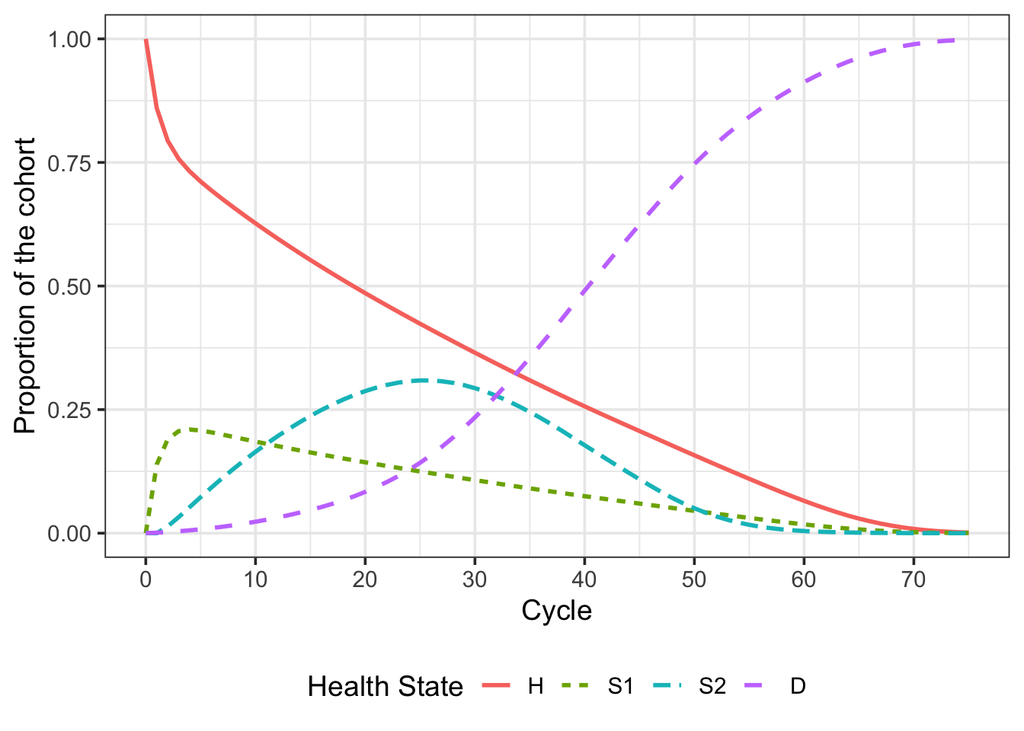

```r
plot_trace(m_M_SoC)
```

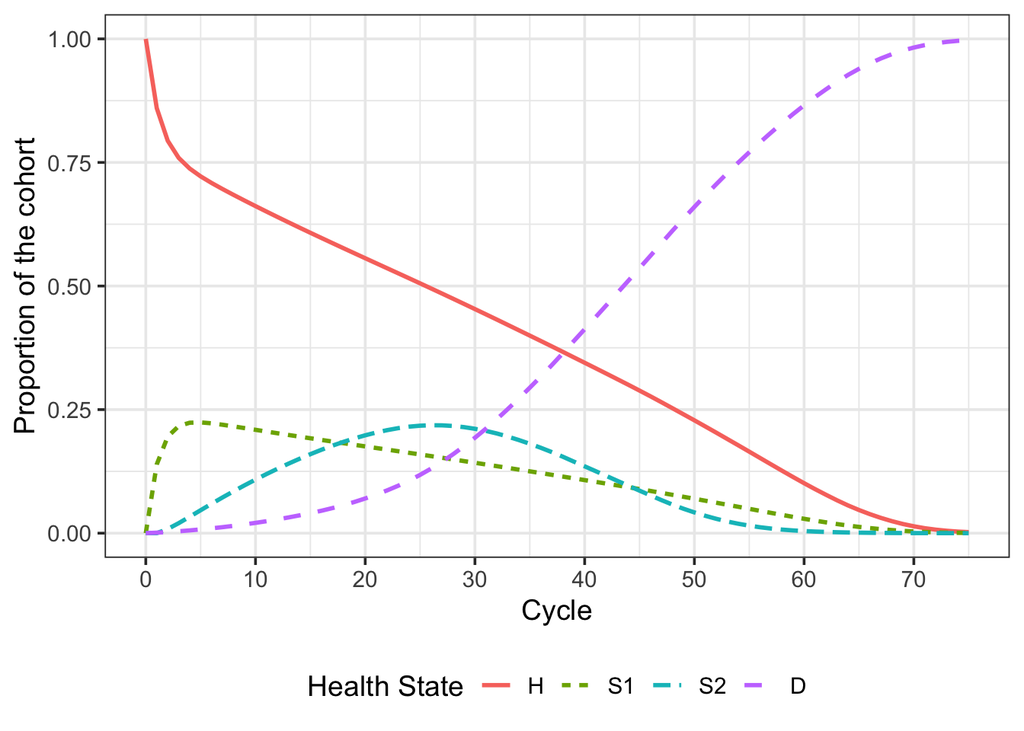

```r
plot_trace(m_M_strAB)
```

# 07 State Rewards

```r
## Scale by the cycle length
# Vector of state utilities under strategy SoC
v_u_SoC    <- c(H  = u_H,
                S1 = u_S1,
                S2 = u_S2,
                D  = u_D) * cycle_length
# Vector of state costs under strategy SoC
v_c_SoC    <- c(H  = c_H,
                S1 = c_S1,
                S2 = c_S2,
                D  = c_D) * cycle_length
# Vector of state utilities under strategy AB
v_u_strAB  <- c(H  = u_H,
                S1 = u_trtAB,
                S2 = u_S2,
                D  = u_D) * cycle_length
# Vector of state costs under strategy AB
v_c_strAB  <- c(H  = c_H,
                S1 = c_S1 + c_trtAB,
                S2 = c_S2 + c_trtAB,
                D  = c_D) * cycle_length

## Store state rewards
# Store the vectors of state utilities for each strategy in a list
l_u <- list(SoC = v_u_SoC,
            AB  = v_u_strAB)
# Store the vectors of state cost for each strategy in a list
l_c <- list(SoC =  v_c_SoC,
            AB  =  v_c_strAB)

# assign strategy names to matching items in the lists
names(l_u) <- names(l_c) <- v_names_str
```

# 08 Compute expected outcomes

```r
# Create empty vectors to store total utilities and costs
v_tot_qaly <- v_tot_cost <- vector(mode = "numeric", length = n_str)
names(v_tot_qaly) <- names(v_tot_cost) <- v_names_str

## Loop through each strategy and calculate total utilities and costs
for (i in 1:n_str) { # i <- 1
  v_u_str <- l_u[[i]]   # select the vector of state utilities for the i-th strategy
  v_c_str <- l_c[[i]]   # select the vector of state costs for the i-th strategy

  ### Expected QALYs and costs per cycle
  ## Vector of QALYs and Costs
  # Apply state rewards
  v_qaly_str <- l_m_M[[i]] %*% v_u_str # sum the utilities of all states for each cycle
  v_cost_str <- l_m_M[[i]] %*% v_c_str # sum the costs of all states for each cycle

  ### Discounted total expected QALYs and Costs per strategy and apply within-cycle correction if applicable
  # QALYs
  v_tot_qaly[i] <- t(v_qaly_str) %*% (v_dwe * v_wcc)
  # Costs
  v_tot_cost[i] <- t(v_cost_str) %*% (v_dwc * v_wcc)
}
```

# 09 Cost-effectiveness analysis (CEA)

```r
## Incremental cost-effectiveness ratios (ICERs)
df_cea <- calculate_icers(cost       = v_tot_cost,
                          effect     = v_tot_qaly,
                          strategies = v_names_str)
df_cea
```

```
##                          Strategy     Cost   Effect Inc_Cost Inc_Effect
## Standard of care Standard of care 155352.9 18.89848       NA         NA
## Strategy AB           Strategy AB 401649.2 21.11782 246296.3   2.219343
##                      ICER Status
## Standard of care       NA     ND
## Strategy AB      110977.1     ND
```

```r
## CEA table in proper format
table_cea <- format_table_cea(df_cea)
table_cea
```

```
##                          Strategy Costs ($) QALYs Incremental Costs ($)
## Standard of care Standard of care   155,353 18.90                  <NA>
## Strategy AB           Strategy AB   401,649 21.12               246,296
##                  Incremental QALYs ICER ($/QALY) Status
## Standard of care                NA          <NA>     ND
## Strategy AB                   2.22       110,977     ND
```

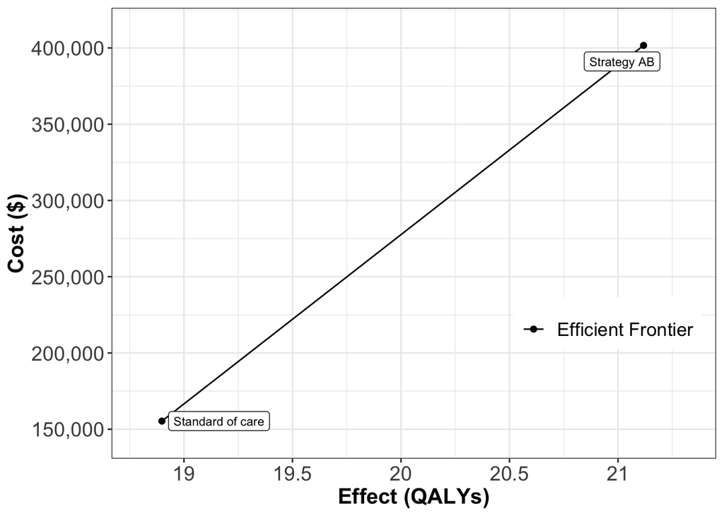

```r
## CEA frontier
plot(df_cea, label = "all", txtsize = 16) +
  expand_limits(x = max(table_cea$QALYs) + 0.1) +
  theme(legend.position = c(0.82, 0.3))
```

We kindly request you to add the following Acknowledgement paragraph to your further work where DARTH code formed the basis. We also like to remind you that you can add other sources of reference to this paragraph to acknowledge code you got from others.

# Acknowlegdement

For this work we made use of the template developed by the Decision Analysis in R for Technologies in Health (DARTH) workgroup: http://darthworkgroup.com.

The notation of our code is based on the following provided framework and coding convention: Alarid-Escudero, F., Krijkamp, E., Pechlivanoglou, P. et al. A Need for Change! A Coding Framework for Improving Transparency in Decision Modeling. PharmacoEconomics 37, 1329–1339 (2019). https://doi.org/10.1007/s40273-019-00837-x.

Other work from DARTH can be found on the website: http://darthworkgroup.com/publications/

# Copyright for assignment work

Copyright 2017, THE HOSPITAL FOR SICK CHILDREN AND THE COLLABORATING INSTITUTIONS.All rights reserved in Canada, the United States and worldwide. Copyright, trademarks, trade names and any and all associated intellectual property are exclusively owned by THE HOSPITAL FOR Sick CHILDREN and the collaborating institutions. These materials may be used, reproduced, modified, distributed and adapted with proper attribution.